# An exploration of fish communities in California MPAs

### Data Description

These datasets are from a summer of data collected in 2023, with the purpose of assessing the possible impacts of marine protected areas (MPAs) on the fish communities they protect. That summer, the Lindholm lab and I completed four week long data collection trips at four different MPAs along California’s central and north coast. We deployed stereo camera systems for 45 minutes each, then took that video back to the lab and spent the fall collecting fish data from it. Stereo video specifically uses two cameras to triangulate objects where the frames overlap, allowing us to measure fish down to the millimeter without ever touching them. These data were eventually processed and submitted to inform MPA management.

Here is the data: https://docs.google.com/spreadsheets/d/1KVd_7IsOHM9Xe1PDIf47Q4LnQt4J6QFjS5UL1i_GzpA/edit?gid=0#gid=0

*Sheets*:

- Drop_data - information on each camera system deployment
- 3D_points - Each individual fish counted
- Lengths - The precise measurement of each fish able to be measured

*Variables of interest*:

- OpCode OR Drop_ID - sample (drop) identifier
- Date - YYYYMMDD, when the video was taken
- Location - the marine protected area that was sampled
- Designation - whether the video was taken inside the MPA or outside (REF)
- 3D Points - number of fish counted in drop
- 3D Lengths - number of fish measured in drop
- Depth (m) - depth of drop in meters
- Simpson_div - Gini-Simpson diversity index
- Shannon_div - Shannon-Wiener diversity index
- Common_name - common name of each species of fish

### Data Cleaning

For the first visualization, I started with the 3D_points data and pulled out just the columns of OpCode and Common_name. Then, grouping by OpCode, I counted the number of unique values for Common_name. This is calculating the number of different species seen per sample, or species richness. I then take this information and add it to the Drop_data sheet. I then make minor changes such as renaming the species richness variable and ordering the locations from south to north before making the visualization.  
For the second visualization, I used the lengths sheet, and pulled out columns Date, Location, Designation, Length (mm), OpCode, and Common_name. I then removed observations of Northern Anchovies. This was a pretty extreme outlier, where in one video, a bait ball of thousands of anchovies swam in view of the cameras. This was severely skewing the data, and only happened in one out of over 200 drops, so it was removed. Then I converted the lengths from millimeters to centimeters and ordered the locations from south to north before making the second visualization.

### Figure 1

Point Lobos has the highest species richness (number of different species), and Montara has the lowest. We would expect that the species richness decreases as we move northward, however, Point Lobos is the oldest State Marine Reserve (no take) in California, likely causing it to have higher richness than the more south Point Buchon. In all but Ano Nuevo, the MPA appears to have higher species richness than the reference site. Ano Nuevo may be an exception to this because it is a hard to access and poorly enforced MPA, likely causing there to be no difference inside and out of the MPA. The strongest difference is in Point Lobos, again likely due to it being the oldest no take zone in California.

[figure not shown]

Figure 1: Species richness is generally higher in MPAs than reference sites

### Figure 2

Ano Nuevo appears to have the largest proportion of large fish. Point Buchon and Point Lobos have a large density of small fish, which are mostly young of the year rockfish, Suggesting these sites serve as nurseries. There is also a higher density as the graph moves from north to south. At our north most sites, there was a lot more sand and mud, as opposed to rocky habitat, so we saw less fish, as most fish like to aggregate over rocky substrate. Additionally, Ano Nuevo did not have many samples due to poor weather, leading to even fewer fish observations. Montara had a lower proportion of large fish, but did have several very large individuals, likely lingcod.

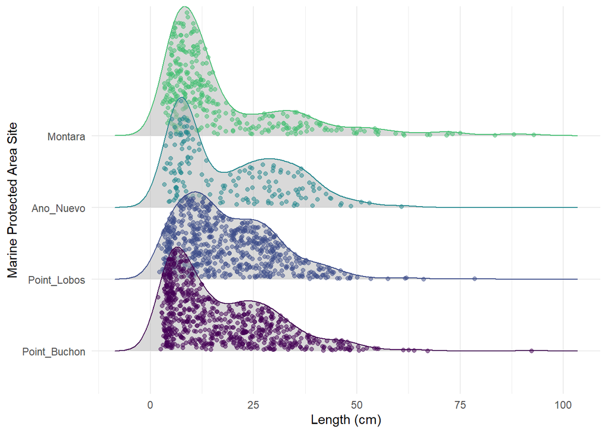

Figure 2: Distributions of fish size by site